# The_Analytics_Edge_edX_MIT15.071x_June2015

### Assignment 2: DETECTING FLU EPIDEMICS VIA SEARCH ENGINE QUERY DATA

Flu epidemics constitute a major public health concern causing respiratory illnesses, hospitalizations, and deaths. According to the National Vital Statistics Reports published in October 2012, influenza ranked as the eighth leading cause of death in 2011 in the United States. Each year, 250,000 to 500,000 deaths are attributed to influenza related diseases throughout the world.

The U.S. Centers for Disease Control and Prevention (CDC) and the European Influenza Surveillance Scheme (EISS) detect influenza activity through virologic and clinical data, including Influenza-like Illness (ILI) physician visits. Reporting national and regional data, however, are published with a 1-2 week lag.

The Google Flu Trends project was initiated to see if faster reporting can be made possible by considering flu-related online search queries – data that is available almost immediately.

PROBLEM 1.1 - UNDERSTANDING THE DATA  
We would like to estimate influenza-like illness (ILI) activity using Google web search logs. Fortunately, one can easily access this data online:

ILI Data - The CDC publishes on its website the official regional and state-level percentage of patient visits to healthcare providers for ILI purposes on a weekly basis.

Google Search Queries - Google Trends allows public retrieval of weekly counts for every query searched by users around the world. For each location, the counts are normalized by dividing the count for each query in a particular week by the total number of online search queries submitted in that location during the week. Then, the values are adjusted to be between 0 and 1.

The csv file FluTrain.csv aggregates this data from January 1, 2004 until December 31, 2011 as follows:

“Week” - The range of dates represented by this observation, in year/month/day format.

“ILI” - This column lists the percentage of ILI-related physician visits for the corresponding week.

“Queries” - This column lists the fraction of queries that are ILI-related for the corresponding week, adjusted to be between 0 and 1 (higher values correspond to more ILI-related search queries).

```r
#lets load the data
FluTrain<-read.csv("FluTrain.csv")
str(FluTrain)
```

```
## 'data.frame':    417 obs. of  3 variables:
##  $ Week   : Factor w/ 417 levels "2004-01-04 - 2004-01-10",..: 1 2 3 4 5 6 7 8 9 10 ...
##  $ ILI    : num  2.42 1.81 1.71 1.54 1.44 ...
##  $ Queries: num  0.238 0.22 0.226 0.238 0.224 ...
```

```r
#Looking at the time period 2004-2011, which week corresponds to the highest percentage of ILI-related physician visits? Select the day of the month corresponding to the start of this week.
subset(FluTrain, ILI == max(ILI)) #or FluTrain$Week[which.max(FluTrain$ILI)]
```

```
##                        Week      ILI Queries
## 303 2009-10-18 - 2009-10-24 7.618892       1
```

```r
#Ans:2009-10-18

#Which week corresponds to the highest percentage of ILI-related query fraction?
subset(FluTrain,Queries==max(Queries)) #or FluTrain$Week[which.max(FluTrain$Queries)]
```

```
##                        Week      ILI Queries
## 303 2009-10-18 - 2009-10-24 7.618892       1
```

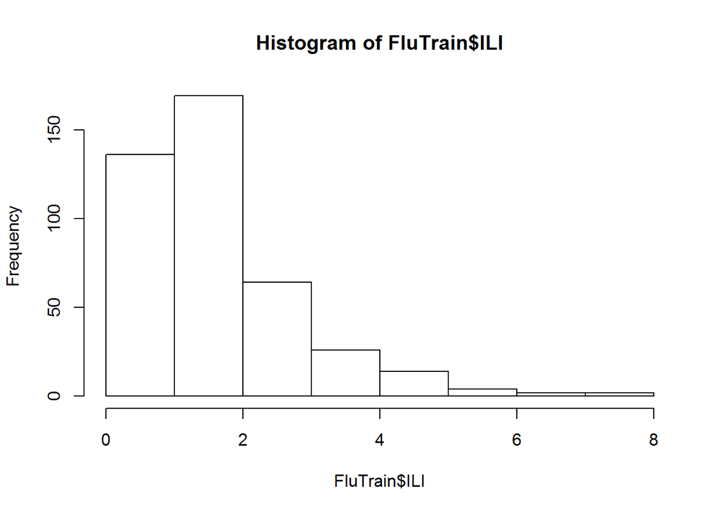

```r
#Ans:2009-10-18

#######################################

#PROBLEM 1.2 - UNDERSTANDING THE DATA

#Let us now understand the data at an aggregate level. Plot the histogram of the dependent variable, ILI. What best describes the distribution of values of ILI?
hist(FluTrain$ILI)
```

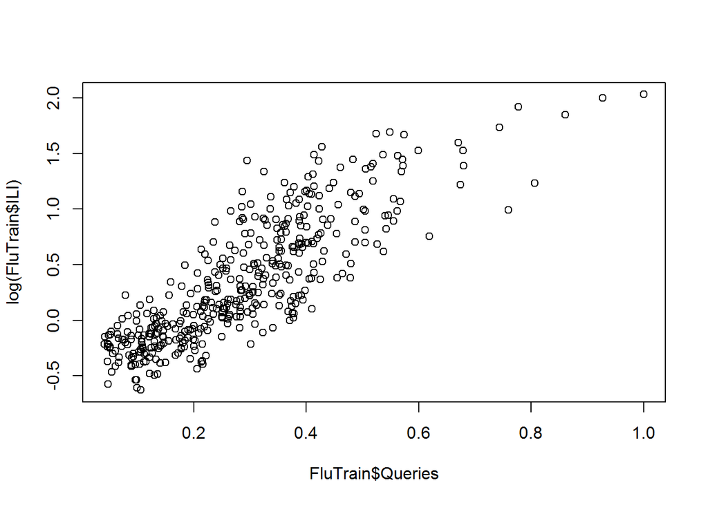

```r
#Ans:Most of the ILI values are small, with a relatively small number of much larger values (in statistics, this sort of data is called "skew right").
# the data is skew right

########################################

#PROBLEM 1.3 - UNDERSTANDING THE DATA

#When handling a skewed dependent variable, it is often useful to predict the logarithm of the dependent variable instead of the dependent variable itself -- this prevents the small number of unusually large or small observations from having an undue influence on the sum of squared errors of predictive models. In this problem, we will predict the natural log of the ILI variable, which can be computed in R using the log() function.

#Plot the natural logarithm of ILI versus Queries. What does the plot suggest?.
plot(FluTrain$Queries,log(FluTrain$ILI))
```

```r
#Ans:There is a positive, linear relationship between log(ILI) and Queries.

###########################################

#PROBLEM 2.1 - LINEAR REGRESSION MODEL

#Based on the plot we just made, it seems that a linear regression model could be a good modeling choice. Based on our understanding of the data from the previous subproblem, which model best describes our estimation problem?
FluTrend1<-lm(log(ILI)~Queries,data=FluTrain)
summary(FluTrend1)
```

```
##
## Call:
## lm(formula = log(ILI) ~ Queries, data = FluTrain)
##
## Residuals:
##      Min       1Q   Median       3Q      Max
## -0.76003 -0.19696 -0.01657  0.18685  1.06450
##
## Coefficients:
##             Estimate Std. Error t value Pr(>|t|)
## (Intercept) -0.49934    0.03041  -16.42   <2e-16 ***
## Queries      2.96129    0.09312   31.80   <2e-16 ***
## ---
## Signif. codes:  0 '***' 0.001 '**' 0.01 '*' 0.05 '.' 0.1 ' ' 1
##
## Residual standard error: 0.2995 on 415 degrees of freedom
## Multiple R-squared:  0.709,  Adjusted R-squared:  0.7083
## F-statistic:  1011 on 1 and 415 DF,  p-value: < 2.2e-16
```

```r
#log(ILI) = intercept + coefficient x Queries, where the coefficient is positive
#XPLANATION:From the previous subproblem, we are predicting log(ILI) using the Queries variable. From the plot in the previous subproblem, we expect the coefficient on Queries to be positive.

#######################################

#PROBLEM 2.2 - LINEAR REGRESSION MODEL

#Let's call the regression model from the previous problem (Problem 2.1) FluTrend1 and run it in R. Hint: to take the logarithm of a variable Var in a regression equation, you simply use log(Var) when specifying the formula to the lm() function.
FluTrend1<-lm(log(ILI)~Queries,data=FluTrain)
summary(FluTrend1)
```

```
##
## Call:
## lm(formula = log(ILI) ~ Queries, data = FluTrain)
##
## Residuals:
##      Min       1Q   Median       3Q      Max
## -0.76003 -0.19696 -0.01657  0.18685  1.06450
##
## Coefficients:
##             Estimate Std. Error t value Pr(>|t|)
## (Intercept) -0.49934    0.03041  -16.42   <2e-16 ***
## Queries      2.96129    0.09312   31.80   <2e-16 ***
## ---
## Signif. codes:  0 '***' 0.001 '**' 0.01 '*' 0.05 '.' 0.1 ' ' 1
##
## Residual standard error: 0.2995 on 415 degrees of freedom
## Multiple R-squared:  0.709,  Adjusted R-squared:  0.7083
## F-statistic:  1011 on 1 and 415 DF,  p-value: < 2.2e-16
```

```r
#What is the training set R-squared value for FluTrend1 model (the "Multiple R-squared")?
#Ans:0.709

##########################################

#PROBLEM 2.3 - LINEAR REGRESSION MODEL

#For a single variable linear regression model, there is a direct relationship between the R-squared and the correlation between the independent and the dependent variables. What is the relationship we infer from our problem? (Don't forget that you can use the cor function to compute the correlation between two variables.)
Correlation<-cor(FluTrain$Queries,log(FluTrain$ILI))
Correlation^2
```

```
## [1] 0.7090201
```

```r
#Ans:R-squared = Correlation^2
#To test these hypotheses, we first need to compute the correlation between the independent variable used in the model (Queries) and the dependent variable (log(ILI)).
log(1/Correlation)
```

```
## [1] 0.1719357
```

```r
exp(-0.5*Correlation)
```

```
## [1] 0.6563792
```

```r
#It appears that Correlation^2 is equal to the R-squared value. It can be proved that this is always the case.

#########################################

#PROBLEM 3.1 - PERFORMANCE ON THE TEST SET

#The csv file FluTest.csv provides the 2012 weekly data of the ILI-related search queries and the observed weekly percentage of ILI-related physician visits.

FluTest<-read.csv("FluTest.csv")

#Normally, we would obtain test-set predictions from the model FluTrend1 using the code

#PredTest1 = predict(FluTrend1, newdata=FluTest)

#However, the dependent variable in our model is log(ILI), so PredTest1 would contain predictions of the log(ILI) value. We are instead interested in obtaining predictions of the ILI value. We can convert from predictions of log(ILI) to predictions of ILI via exponentiation, or the exp() function. The new code, which predicts the ILI value, is

PredTest1 = exp(predict(FluTrend1, newdata=FluTest))

#What is our estimate for the percentage of ILI-related physician visits for the week of March 11, 2012? (HINT: You can either just output FluTest$Week to find which element corresponds to March 11, 2012, or you can use the "which" function in R. To learn more about the which function, type ?which in your R console.)
PredTest1[which(FluTest$Week=="2012-03-11 - 2012-03-17")]
```

```
##       11
## 2.187378
```

```r
#Ans:2.187383

###########################################

#PROBLEM 3.2 - PERFORMANCE ON THE TEST SET

#What is the relative error betweeen the estimate (our prediction) and the observed value for the week of March 11, 2012? Note that the relative error is calculated as
#(Observed ILI - Estimated ILI)/Observed ILI
FluTest$ILI[which(FluTest$Week=="2012-03-11 - 2012-03-17")]
```

```
## [1] 2.293422
```

```r
(2.293422-2.187383)/2.293422
```

```
## [1] 0.04623615
```

```r
#Ans:0.04623615
#EXPLANATION:From the previous problem, we know the predicted value is 2.187378. The actual value is the 11th testing set ILI value or FluTest$ILI[11], which has value 2.293422. Finally we compute the relative error to be (2.293422 - 2.187378)/2.293422.

######################################

#PROBLEM 3.3 - PERFORMANCE ON THE TEST SET

#What is the Root Mean Square Error (RMSE) between our estimates and the actual observations for the percentage of ILI-related physician visits, on the test set?
#lets use long hand method (a.k.a using formula)
SSE = sum((PredTest1 - FluTest$ILI)^2)
# Compute the RMSE
sqrt(mean((PredTest1-FluTest$ILI)^2)) # orRMSE = sqrt(SSE / nrow(FluTest))
```

```
## [1] 0.7490645
```

```r
#Ans: 0.7490645

############################################

#PROBLEM 4.1 - TRAINING A TIME SERIES MODEL

#The observations in this dataset are consecutive weekly measurements of the dependent and independent variables. This sort of dataset is called a "time series." Often, statistical models can be improved by predicting the current value of the dependent variable using the value of the dependent variable from earlier weeks. In our models, this means we will predict the ILI variable in the current week using values of the ILI variable from previous weeks.

#First, we need to decide the amount of time to lag the observations. Because the ILI variable is reported with a 1- or 2-week lag, a decision maker cannot rely on the previous week's ILI value to predict the current week's value. Instead, the decision maker will only have data available from 2 or more weeks ago. We will build a variable called ILILag2 that contains the ILI value from 2 weeks before the current observation.

#To do so, we will use the "zoo" package, which provides a number of helpful methods for time series models. While many functions are built into R, you need to add new packages to use some functions. New packages can be installed and loaded easily in R, and we will do this many times in this class. Run the following two commands to install and load the zoo package. In the first command, you will be prompted to select a CRAN mirror to use for your download. Select a mirror near you geographically.

library(zoo)
#After installing and loading the zoo package, run the following commands to create the ILILag2 variable in the training set:

ILILag2 = lag(zoo(FluTrain$ILI), k=-2, na.pad=TRUE)

FluTrain$ILILag2 = coredata(ILILag2)

#In these commands, the value of -2 passed to lag means to return 2 observations before the current one; a positive value would have returned future observations. The parameter na.pad=TRUE means to add missing values for the first two weeks of our dataset, where we can't compute the data from 2 weeks earlier.

#How many values are missing in the new ILILag2 variable?
sum(is.na(FluTrain$ILILag2))  #or summary(FluTrain$ILILag2)
```

[output not shown]